# Enjoy Mushrooms!

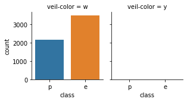

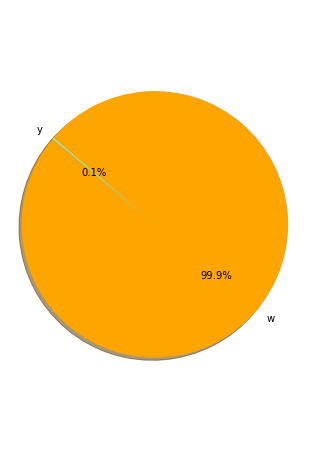

```python
get_plots('veil-color');get_pie_chart(17,18)
```

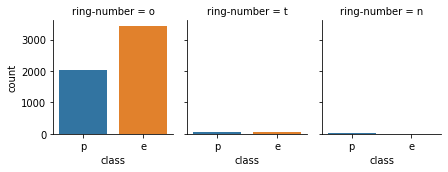

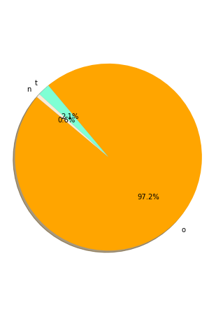

```python
get_plots('ring-number');get_pie_chart(18,19)
```

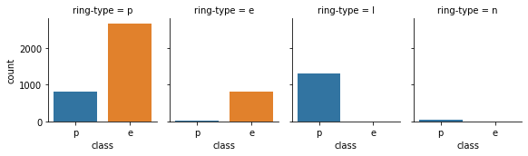

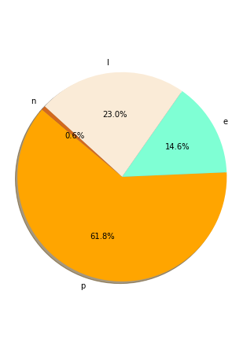

```python
get_plots('ring-type');get_pie_chart(19,20)
```

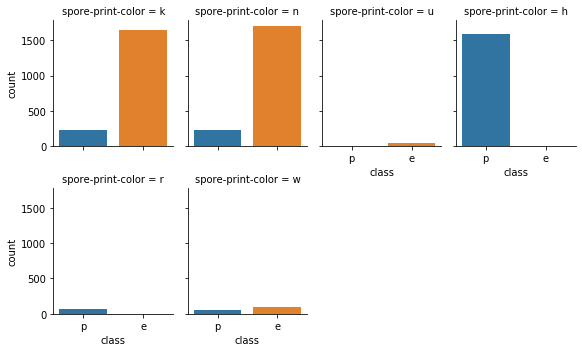

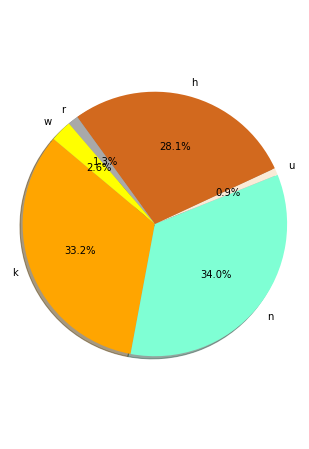

```python
get_plots('spore-print-color');get_pie_chart(20,21)
```

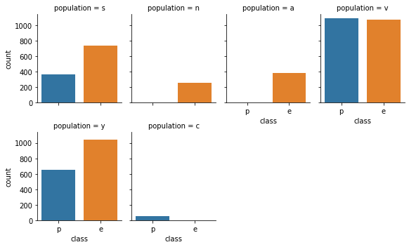

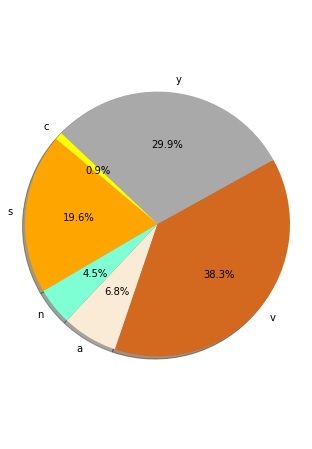

```python
get_plots('population');get_pie_chart(21,22)
```

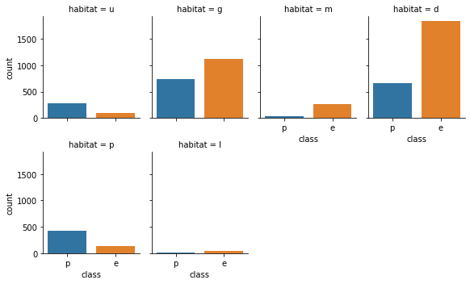

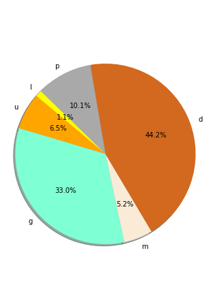

```python
get_plots('habitat');get_pie_chart(22,23)
```

## Data modeling

This section will apply several classification algorithms to the dataset. We are looking for those algorithms with the best accuracy metric.

```python
from sklearn.model_selection import train_test_split, cross_val_score, cross_val_predict
from sklearn.tree import DecisionTreeClassifier
from sklearn.ensemble import BaggingClassifier
from sklearn import neighbors
from sklearn.svm import SVC
from sklearn.naive_bayes import GaussianNB
from sklearn.decomposition import PCA
import xgboost as xgb
# to create confusion matrix
from sklearn.metrics import accuracy_score, confusion_matrix, precision_recall_fscore_support
import matplotlib.pyplot as plt
import seaborn as sns
# AVOID WARNING MESSAGES
import warnings
warnings.filterwarnings('ignore')
import seaborn as sns
import time
```

```python
from sklearn.preprocessing import LabelEncoder

df_aux = df.copy(deep=True)
labelencoder=LabelEncoder()
for col in df_aux.columns:
    df_aux[col] = labelencoder.fit_transform(df_aux[col])
df_aux.head()
```

|  | class | cap-shape | cap-surface | cap-color | bruises | odor | gill-attachment | gill-spacing | gill-size | gill-color | ... | stalk-surface-below-ring | stalk-color-above-ring | stalk-color-below-ring | veil-type | veil-color | ring-number | ring-type | spore-print-color | population | habitat |
| --- | --- | --- | --- | --- | --- | --- | --- | --- | --- | --- | --- | --- | --- | --- | --- | --- | --- | --- | --- | --- | --- |
| 0 | 1 | 5 | 2 | 4 | 1 | 6 | 1 | 0 | 1 | 2 | ... | 2 | 5 | 5 | 0 | 0 | 1 | 3 | 1 | 3 | 5 |
| 1 | 0 | 5 | 2 | 7 | 1 | 0 | 1 | 0 | 0 | 2 | ... | 2 | 5 | 5 | 0 | 0 | 1 | 3 | 2 | 2 | 1 |
| 2 | 0 | 0 | 2 | 6 | 1 | 3 | 1 | 0 | 0 | 3 | ... | 2 | 5 | 5 | 0 | 0 | 1 | 3 | 2 | 2 | 3 |
| 3 | 1 | 5 | 3 | 6 | 1 | 6 | 1 | 0 | 1 | 3 | ... | 2 | 5 | 5 | 0 | 0 | 1 | 3 | 1 | 3 | 5 |
| 4 | 0 | 5 | 2 | 3 | 0 | 5 | 1 | 1 | 0 | 2 | ... | 2 | 5 | 5 | 0 | 0 | 1 | 0 | 2 | 0 | 1 |

5 rows × 23 columns

```python
cols = ['cap-shape','cap-surface','cap-color','odor','gill-color','stalk-root','stalk-surface-above-ring','stalk-surface-below-ring','stalk-color-above-ring','stalk-color-below-ring','veil-color','ring-number','ring-type','spore-print-color','population','habitat']

df_num = pd.get_dummies(df[cols])
df_num = df_aux.join(df_num)
df_num = df_num.drop(cols,axis=1)
df_num.head()
```

|  | class | bruises | gill-attachment | gill-spacing | gill-size | stalk-shape | veil-type | cap-shape_b | cap-shape_c | cap-shape_f | ... | population_n | population_s | population_v | population_y | habitat_d | habitat_g | habitat_l | habitat_m | habitat_p | habitat_u |
| --- | --- | --- | --- | --- | --- | --- | --- | --- | --- | --- | --- | --- | --- | --- | --- | --- | --- | --- | --- | --- | --- |
| 0 | 1 | 1 | 1 | 0 | 1 | 0 | 0 | 0 | 0 | 0 | ... | 0 | 1 | 0 | 0 | 0 | 0 | 0 | 0 | 0 | 1 |
| 1 | 0 | 1 | 1 | 0 | 0 | 0 | 0 | 0 | 0 | 0 | ... | 1 | 0 | 0 | 0 | 0 | 1 | 0 | 0 | 0 | 0 |
| 2 | 0 | 1 | 1 | 0 | 0 | 0 | 0 | 1 | 0 | 0 | ... | 1 | 0 | 0 | 0 | 0 | 0 | 0 | 1 | 0 | 0 |
| 3 | 1 | 1 | 1 | 0 | 1 | 0 | 0 | 0 | 0 | 0 | ... | 0 | 1 | 0 | 0 | 0 | 0 | 0 | 0 | 0 | 1 |
| 4 | 0 | 0 | 1 | 1 | 0 | 1 | 0 | 0 | 0 | 0 | ... | 0 | 0 | 0 | 0 | 0 | 1 | 0 | 0 | 0 | 0 |

5 rows × 94 columns

```python
x = df_num.iloc[:,1:len(df_num)]
y = df_num.iloc[:, 0]
x_train,x_test,y_train,y_test = train_test_split(x,y,test_size = 0.3,random_state = 1)
```

### Decision Trees

We'll use 70% of the dataset, and for the second one a 30%.

Let's try a Hold-Out evaluation first:

```python
clf=DecisionTreeClassifier()
clf=clf.fit(x_train, y_train)
y_pred=clf.predict(x_test)
acc=accuracy_score(y_pred, y_test)
print('Tree Accuracy by hold-out evaluation: ',acc)
```

```
Tree Accuracy by hold-out evaluation:  1.0
```

As we can see the accuracy for the algorithm is 100% which is unreal, so let's try this time N-fold Cross validation.

```python
clf=DecisionTreeClassifier()
acc_nfold_dt = cross_val_score(clf, x, y, cv=5, scoring='accuracy').mean()

start_kfold_dt = time.clock()
y_pred = cross_val_predict(clf, x, y, cv=5)
end_kfold_dt = time.clock() - start_kfold_dt
kfold_time_dt = end_kfold_dt

print("Tree Accuracy by N-fold Cross Validation:", acc_nfold_dt)
```

```
Tree Accuracy by N-fold Cross Validation: 0.9397966484654491
```

We have an accurary of 93%, which is closer to reality. What has happened before is because the dataset may be too smail to perform a Hold-Out evaluation.

```
      0     1
0  3392    96
1   292  1864
```

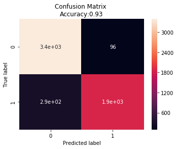

```python
get_conf_matrix(y, y_pred)
```

You'll notice that there are two more corners remaining. The top one is for what is called 'false positives'. That means that the algorithm classified that instance as true but it was actually false. The opposite happens with the bottom left corner ('false negative').

### Random Forest

```python
tree = DecisionTreeClassifier()
bag = BaggingClassifier(tree, n_estimators=100, max_samples=0.8, random_state=1)
acc_nfold_rf=cross_val_score(bag, x, y, cv=5, scoring='accuracy').mean()

start_kfold_rf = time.clock()
y_pred = cross_val_predict(bag, x, y, cv=5)
end_kfold_rf = time.clock() - start_kfold_rf
kfold_time_rf = end_kfold_rf

print("RandomForest Accuracy by N-fold Cross Validation:",acc_nfold_rf)
```

```
RandomForest Accuracy by N-fold Cross Validation: 0.9312860101675767
```

```python
kfold_time_rf
```

```
12.748223
```

```
      0     1
0  3392    96
1   292  1864
```

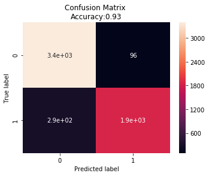

```python
get_conf_matrix(y, y_pred)
```

### K-Nearest Neighbor

We have to normalize the variables values so that they are between 1 and 0. If we didn't take this step, the distance calculated by the KNN would be seen affected, and therefore, the accuracy of the model created.

```python
df_knn = df_num.copy(deep=True)

x_knn = df_knn.iloc[:,1:len(df_knn)]
y_knn = df_knn.iloc[:, 0]

x_train_knn, x_test_knn, y_train_knn, y_test_knn = train_test_split(df_knn, y_knn, test_size=0.2)
```

```python
clf=neighbors.KNeighborsClassifier(3, weights='uniform')
clf.fit(x_train_knn, y_train_knn)
y_pred_knn = clf.predict(x_test_knn)
print('K =', 3, ', Accuracy by Hold-Out: ', accuracy_score(y_test_knn, y_pred_knn))
```

```
K = 3 , Accuracy by Hold-Out:  1.0
```

```python
clf=neighbors.KNeighborsClassifier(3, weights='uniform')
acc_nfold_knn=cross_val_score(clf, x_knn, y_knn, cv=5, scoring='accuracy').mean()

start_kfold_knn = time.clock()
y_pred = cross_val_predict(clf, x_knn, y_knn, cv=5)
end_kfold_knn = time.clock() - start_kfold_knn
kfold_time_knn = end_kfold_knn

print('K =', 3, ', Accuracy by N-Fold: ',acc_nfold_knn)
```

```
K = 3 , Accuracy by N-Fold:  0.9435140902529342
```

```python
kfold_time_knn
```

```
6.383747
```

```
      0     1
0  3396    92
1   256  1900
```

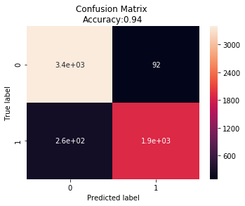

```python
get_conf_matrix(y_knn, y_pred)
```

### SVM

```python
clf=SVC(kernel='linear', C=1E10)
start_kfold_svm = time.clock()
y_pred = cross_val_predict(clf, x_knn, y_knn, cv=5)
end_kfold_svm = time.clock() - start_kfold_svm
kfold_time_svm = end_kfold_svm

acc_nfold_svm=cross_val_score(clf, x_knn, y_knn, cv=5, scoring='accuracy').mean()
print("Linear Accuracy by N-fold Cross Validation:",acc_nfold_svm)


clf=SVC(kernel='rbf', C=1E10)
acc=cross_val_score(clf, x_knn, y_knn, cv=5, scoring='accuracy').mean()
print("RBF Accuracy by N-fold Cross Validation:",acc)
```

```
Linear Accuracy by N-fold Cross Validation: 0.9362505491746689
RBF Accuracy by N-fold Cross Validation: 0.9362505491746689
```

```
      0     1
0  3488     0
1   300  1856
```

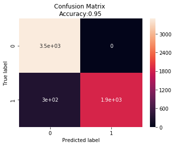

```python
get_conf_matrix(y_knn, y_pred)
```

### Naïves-Bayes

```python
clf = GaussianNB()
clf.fit(x_train,y_train)
y_pred = clf.predict(x_test)

print('Accuracy by Hold-Out Validation: ',clf.score(x_test,y_test))
```

```
Accuracy by Hold-Out Validation:  0.9982290436835891
```

```python
clf = GaussianNB()
acc_nfold_nb=cross_val_score(clf, x, y, cv=5, scoring='accuracy').mean()

start_kfold_nb = time.clock()
y_pred = cross_val_predict(clf, x, y, cv=5)
end_kfold_nb = time.clock() - start_kfold_nb
kfold_time_nb = end_kfold_nb

print("Accuracy by N-fold Cross Validation:",acc_nfold_nb)
```

```
Accuracy by N-fold Cross Validation: 0.9369597690328251
```

```
      0     1
0  3392    96
1   260  1896
```

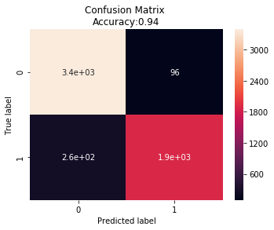

```python
get_conf_matrix(y, y_pred)
```

### XG Boosting

```python
xg_reg = xgb.XGBClassifier()
acc_nfold_xg=cross_val_score(xg_reg, x, y, cv=5, scoring='accuracy').mean()

start_kfold_xg = time.clock()
y_pred = cross_val_predict(xg_reg, x, y, cv=5)
end_kfold_xg = time.clock() - start_kfold_xg
kfold_time_xg = end_kfold_xg

print("Tree Accuracy by N-fold Cross Validation:", acc_nfold_xg)
```

```
Tree Accuracy by N-fold Cross Validation: 0.9298675704512647
```

```
      0     1
0  3392    96
1   300  1856
```

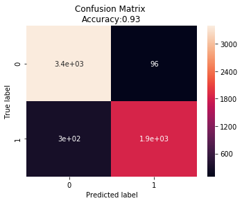

```python
get_conf_matrix(y, y_pred)
```

### Feature Redution using PCA

```python
y=df_num['class']
x=df_num.drop('class',axis=1)

pca = PCA(n_components=7)
fit = pca.fit(x)

print('Explained variance: ', fit.explained_variance_ratio_)
print('\nPCAs:\n', fit.components_)

PCAs = pca.fit_transform(x)
PCAs_selected = PCAs[:,:3]
```

[output not shown]

[output cut: 117 more lines]

[output not shown]

```python
clf=DecisionTreeClassifier()
acc_nfold_dt_pca = cross_val_score(clf, PCAs_selected, y, cv=5, scoring='accuracy').mean()

start_kfold_dt_pca = time.clock()
y_pred = cross_val_predict(clf, PCAs_selected, y, cv=5)
end_kfold_dt_pca = time.clock() - start_kfold_dt_pca
kfold_time_dt_pca = end_kfold_dt_pca

print("Tree Accuracy by N-fold Cross Validation:", acc_nfold_dt_pca)
```

```
Tree Accuracy by N-fold Cross Validation: 0.9567804263613404
```

```python
tree = DecisionTreeClassifier()
bag = BaggingClassifier(tree, n_estimators=100, max_samples=0.8, random_state=1)
acc_nfold_rf_pca=cross_val_score(bag, PCAs_selected, y, cv=5, scoring='accuracy').mean()

start_kfold_rf_pca = time.clock()
y_pred = cross_val_predict(bag, PCAs_selected, y, cv=5)
end_kfold_rf_pca = time.clock() - start_kfold_rf_pca
kfold_time_rf_pca = end_kfold_rf_pca

print("Random Forest Accuracy by N-fold Cross Validation:",acc_nfold_rf_pca)
```

```
Random Forest Accuracy by N-fold Cross Validation: 0.9364269143646637
```

```python
clf=neighbors.KNeighborsClassifier(3, weights='uniform')
acc_nfold_knn_pca=cross_val_score(clf, PCAs_selected, y, cv=5, scoring='accuracy').mean()

start_kfold_knn_pca = time.clock()
y_pred = cross_val_predict(clf, PCAs_selected, y, cv=5)
end_kfold_knn_pca = time.clock() - start_kfold_knn_pca
kfold_time_knn_pca = end_kfold_knn_pca

print('K =', 3, ', Accuracy by N-Fold Cross Validation: ',acc_nfold_knn_pca)
```

```
K = 3 , Accuracy by N-Fold Cross Validation:  0.955545880593764
```

```python
# GETS STUCK

clf=SVC(kernel='linear', C=1E10)

start_kfold_svm_pca = time.clock()
y_pred = cross_val_predict(clf, PCAs_selected, y, cv=5)
end_kfold_svm_pca = time.clock() - start_kfold_svm_pca
kfold_time_svm_pca = end_kfold_svm_pca

acc_nfold_svm_pca=cross_val_score(clf, PCAs_selected, y, cv=5, scoring='accuracy').mean()
print("Accuracy by N-fold Cross Validation:",acc_nfold_svm_pca)
```

```python
clf = GaussianNB()
acc_nfold_nb_pca=cross_val_score(clf, PCAs_selected, y, cv=5, scoring='accuracy').mean()

start_kfold_nb_pca = time.clock()
y_pred = cross_val_predict(clf, PCAs_selected, y, cv=5)
end_kfold_nb_pca = time.clock() - start_kfold_nb_pca
kfold_time_nb_pca = end_kfold_nb_pca

print("Accuracy by N-fold Cross Validation:",acc_nfold_nb_pca)
```

```
Accuracy by N-fold Cross Validation: 0.8933843441065796
```

```python
kfold_time_nb_pca
```

```
0.08081199999999455
```

```python
xg_reg = xgb.XGBClassifier()
acc_nfold_xg_pca=cross_val_score(xg_reg, PCAs_selected, y, cv=5, scoring='accuracy').mean()

start_kfold_xg_pca = time.clock()
y_pred = cross_val_predict(xg_reg, PCAs_selected, y, cv=5)
end_kfold_xg_pca = time.clock() - start_kfold_xg_pca
kfold_time_xg_pca = end_kfold_xg_pca

print("Tree Accuracy by N-fold Cross Validation:", acc_nfold_xg_pca)
```

```
Tree Accuracy by N-fold Cross Validation: 0.9314670839588075
```

### Feature Selection with Filter Model

```python
plt.figure(figsize=(12,10))
cor = df_num.corr()
#sns.heatmap(cor, annot=True, cmap=plt.cm.Reds)
#plt.show()
```

```python
#Correlation with output variable
cor_target = abs(cor["class"])
#Selecting highly correlated features
relevant_features = cor_target[cor_target>0.4]
print('\nSelected features by Filter model:\n',relevant_features)
```

```
Selected features by Filter model:
 class                         1.000000
bruises                       0.435562
stalk-shape                   0.592446
odor_f                        0.794472
odor_n                        0.709304
stalk-surface-above-ring_k    0.706930
stalk-surface-above-ring_s    0.582121
stalk-surface-below-ring_k    0.694419
stalk-surface-below-ring_s    0.514371
ring-type_l                   0.694419
spore-print-color_h           0.794472
Name: class, dtype: float64
```

```python
x_filtered_numerical = df_knn[relevant_features.index].drop('class',1)
#x_filtered_nominal = df[relevant_features.index].drop('class',1)
y = df['class']
x_filtered_numerical.head()
```

|  | bruises | stalk-shape | odor_f | odor_n | stalk-surface-above-ring_k | stalk-surface-above-ring_s | stalk-surface-below-ring_k | stalk-surface-below-ring_s | ring-type_l | spore-print-color_h |
| --- | --- | --- | --- | --- | --- | --- | --- | --- | --- | --- |
| 0 | 1 | 0 | 0 | 0 | 0 | 1 | 0 | 1 | 0 | 0 |
| 1 | 1 | 0 | 0 | 0 | 0 | 1 | 0 | 1 | 0 | 0 |
| 2 | 1 | 0 | 0 | 0 | 0 | 1 | 0 | 1 | 0 | 0 |
| 3 | 1 | 0 | 0 | 0 | 0 | 1 | 0 | 1 | 0 | 0 |
| 4 | 0 | 1 | 0 | 1 | 0 | 1 | 0 | 1 | 0 | 0 |

```python
clf=DecisionTreeClassifier()
acc_nfold_dt_fil = cross_val_score(clf, x_filtered_numerical, y, cv=5, scoring='accuracy').mean()

start_kfold_dt_fil = time.clock()
y_pred = cross_val_predict(clf, x_filtered_numerical, y, cv=5)
end_kfold_dt_fil = time.clock() - start_kfold_dt_fil
kfold_time_dt_fil = end_kfold_dt_fil

print("Tree Accuracy by N-fold Cross Validation:", acc_nfold_dt_fil)
```

```
Tree Accuracy by N-fold Cross Validation: 0.9475980669051653
```

```python
tree = DecisionTreeClassifier()
bag = BaggingClassifier(tree, n_estimators=100, max_samples=0.8, random_state=1)
acc_nfold_rf_fil=cross_val_score(bag, x_filtered_numerical, y, cv=5, scoring='accuracy').mean()

start_kfold_rf_fil = time.clock()
y_pred = cross_val_predict(bag, x_filtered_numerical, y, cv=5)
end_kfold_rf_fil = time.clock() - start_kfold_rf_fil
kfold_time_rf_fil = end_kfold_rf_fil

print("Random Forest Accuracy by N-fold Cross Validation:",acc_nfold_rf_fil)
```

```
Random Forest Accuracy by N-fold Cross Validation: 0.9475980669051653
```

```python
clf=neighbors.KNeighborsClassifier(3, weights='uniform')
acc_nfold_knn_fil=cross_val_score(clf, x_filtered_numerical, y, cv=5, scoring='accuracy').mean()

start_kfold_knn_fil = time.clock()
y_pred = cross_val_predict(clf, x_filtered_numerical, y, cv=5)
end_kfold_knn_fil = time.clock() - start_kfold_knn_fil
kfold_time_knn_fil = end_kfold_knn_fil

print('K =', 3, ', Accuracy by N-Fold Cross Validation: ',acc_nfold_knn_fil)
```

```
K = 3 , Accuracy by N-Fold Cross Validation:  0.9199629916173
```

```python
clf=SVC(kernel='linear', C=1E10)

start_kfold_svm_fil = time.clock()
y_pred = cross_val_predict(clf, x_filtered_numerical, y, cv=5)
end_kfold_svm_fil = time.clock() - start_kfold_svm_fil
kfold_time_svm_fil = end_kfold_knn_fil

acc_nfold_svm_fil = cross_val_score(clf, x_filtered_numerical, y, cv=5, scoring='accuracy').mean()
print("Accuracy by N-fold Cross Validation:",acc_nfold_svm_fil)
```

[output not shown]

```python
clf = GaussianNB()
acc_nfold_nb_fil=cross_val_score(clf, x_filtered_numerical, y, cv=5, scoring='accuracy').mean()

start_kfold_nb_fil = time.clock()
y_pred = cross_val_predict(clf, x_filtered_numerical, y, cv=5)
end_kfold_nb_fil = time.clock() - start_kfold_nb_fil
kfold_time_nb_fil = end_kfold_nb_fil

print("Accuracy by N-fold Cross Validation:",acc_nfold_nb_fil)
```

```
Accuracy by N-fold Cross Validation: 0.9050864717661542
```

```python
kfold_time_nb_fil
```

```
0.2092129999999912
```

```python
xg_reg = xgb.XGBClassifier()
acc_nfold_xg_fil=cross_val_score(xg_reg, PCAs_selected, y, cv=5, scoring='accuracy').mean()

start_kfold_xg_fil = time.clock()
y_pred = cross_val_predict(xg_reg, x_filtered_numerical, y, cv=5)
end_kfold_xg_fil = time.clock() - start_kfold_xg_fil
kfold_time_xg_fil = end_kfold_xg_fil

print("Tree Accuracy by N-fold Cross Validation:", acc_nfold_xg_fil)
```

```
Tree Accuracy by N-fold Cross Validation: 0.9314670839588075
```

### Association Rules

```python
#from apyori import apriori
from mlxtend.frequent_patterns import apriori
from mlxtend.frequent_patterns import association_rules
```

```python
df_rules = df_knn[relevant_features.index]

df_aux = pd.get_dummies(df[['class','bruises','stalk-shape']])
df_rules = df_rules.join(df_aux)
df_rules = df_rules.drop(['class','bruises','stalk-shape'],axis=1)
df_rules.head()
```

|  | odor_f | odor_n | stalk-surface-above-ring_k | stalk-surface-above-ring_s | stalk-surface-below-ring_k | stalk-surface-below-ring_s | ring-type_l | spore-print-color_h | class_e | class_p | bruises_f | bruises_t | stalk-shape_e | stalk-shape_t |
| --- | --- | --- | --- | --- | --- | --- | --- | --- | --- | --- | --- | --- | --- | --- |
| 0 | 0 | 0 | 0 | 1 | 0 | 1 | 0 | 0 | 0 | 1 | 0 | 1 | 1 | 0 |
| 1 | 0 | 0 | 0 | 1 | 0 | 1 | 0 | 0 | 1 | 0 | 0 | 1 | 1 | 0 |
| 2 | 0 | 0 | 0 | 1 | 0 | 1 | 0 | 0 | 1 | 0 | 0 | 1 | 1 | 0 |
| 3 | 0 | 0 | 0 | 1 | 0 | 1 | 0 | 0 | 0 | 1 | 0 | 1 | 1 | 0 |
| 4 | 0 | 1 | 0 | 1 | 0 | 1 | 0 | 0 | 1 | 0 | 1 | 0 | 0 | 1 |

```python
frequent_itemsets = apriori(df_rules, min_support=0.07, use_colnames=True)
rules = association_rules(frequent_itemsets, metric="lift", min_threshold=1)
rules.sort_values(by='lift', inplace=True, ascending=False)
rules["antecedent_len"] = rules["antecedents"].apply(lambda x: len(x))
rules = rules[rules['antecedent_len'] <= 4]
rules_p = rules[(rules['consequents'] == {'class_p'})]
rules_e = rules[(rules['consequents'] == {'class_e'})]
```

```python
rules_p.head(10)
```

|  | antecedents | consequents | antecedent support | consequent support | support | confidence | lift | leverage | conviction | antecedent_len |
| --- | --- | --- | --- | --- | --- | --- | --- | --- | --- | --- |
| 533 | (spore-print-color_h, ring-type_l) | (class_p) | 0.229624 | 0.381999 | 0.229624 | 1.0 | 2.617811 | 0.141908 | inf | 2 |
| 134 | (odor_f, stalk-surface-below-ring_k) | (class_p) | 0.229624 | 0.381999 | 0.229624 | 1.0 | 2.617811 | 0.141908 | inf | 2 |
| 63 | (ring-type_l) | (class_p) | 0.229624 | 0.381999 | 0.229624 | 1.0 | 2.617811 | 0.141908 | inf | 1 |
| 364 | (stalk-surface-above-ring_k, stalk-shape_e) | (class_p) | 0.236003 | 0.381999 | 0.236003 | 1.0 | 2.617811 | 0.145850 | inf | 2 |
| 488 | (stalk-shape_e, stalk-surface-below-ring_k) | (class_p) | 0.229624 | 0.381999 | 0.229624 | 1.0 | 2.617811 | 0.141908 | inf | 2 |
| 49 | (stalk-surface-below-ring_k) | (class_p) | 0.229624 | 0.381999 | 0.229624 | 1.0 | 2.617811 | 0.141908 | inf | 1 |
| 482 | (stalk-surface-below-ring_k, bruises_f) | (class_p) | 0.229624 | 0.381999 | 0.229624 | 1.0 | 2.617811 | 0.141908 | inf | 2 |
| 3716 | (spore-print-color_h, stalk-shape_e, stalk-sur... | (class_p) | 0.229624 | 0.381999 | 0.229624 | 1.0 | 2.617811 | 0.141908 | inf | 4 |
| 558 | (stalk-shape_e, ring-type_l) | (class_p) | 0.229624 | 0.381999 | 0.229624 | 1.0 | 2.617811 | 0.141908 | inf | 2 |
| 1408 | (spore-print-color_h, stalk-surface-above-ring... | (class_p) | 0.229624 | 0.381999 | 0.229624 | 1.0 | 2.617811 | 0.141908 | inf | 3 |

```python
rules_e.head(10)
```

|  | antecedents | consequents | antecedent support | consequent support | support | confidence | lift | leverage | conviction | antecedent_len |
| --- | --- | --- | --- | --- | --- | --- | --- | --- | --- | --- |
| 269 | (odor_n, stalk-shape_t) | (class_e) | 0.442240 | 0.618001 | 0.442240 | 1.0 | 1.618119 | 0.168935 | inf | 2 |
| 3035 | (odor_n, stalk-surface-above-ring_s, bruises_t... | (class_e) | 0.306166 | 0.618001 | 0.306166 | 1.0 | 1.618119 | 0.116955 | inf | 4 |
| 1213 | (odor_n, stalk-surface-below-ring_s, stalk-sha... | (class_e) | 0.374203 | 0.618001 | 0.374203 | 1.0 | 1.618119 | 0.142945 | inf | 3 |
| 587 | (bruises_f, stalk-shape_t) | (class_e) | 0.136074 | 0.618001 | 0.136074 | 1.0 | 1.618119 | 0.051980 | inf | 2 |
| 2975 | (odor_n, stalk-surface-above-ring_s, stalk-sur... | (class_e) | 0.340184 | 0.618001 | 0.340184 | 1.0 | 1.618119 | 0.129950 | inf | 4 |
| 3066 | (odor_n, bruises_t, stalk-surface-below-ring_s... | (class_e) | 0.306166 | 0.618001 | 0.306166 | 1.0 | 1.618119 | 0.116955 | inf | 4 |
| 1188 | (odor_n, bruises_f, stalk-surface-below-ring_s) | (class_e) | 0.089298 | 0.618001 | 0.089298 | 1.0 | 1.618119 | 0.034112 | inf | 3 |
| 1241 | (odor_n, bruises_f, stalk-shape_t) | (class_e) | 0.136074 | 0.618001 | 0.136074 | 1.0 | 1.618119 | 0.051980 | inf | 3 |
| 1253 | (odor_n, bruises_t, stalk-shape_t) | (class_e) | 0.306166 | 0.618001 | 0.306166 | 1.0 | 1.618119 | 0.116955 | inf | 3 |
| 1161 | (odor_n, stalk-surface-above-ring_s, stalk-sha... | (class_e) | 0.374203 | 0.618001 | 0.374203 | 1.0 | 1.618119 | 0.142945 | inf | 3 |

## Conclusions

To end up this project, I have performed two analysis. One of them is going to compare the accuracies of each algorithm depending on whether we have applied feature reduction, feature selection or none of them.

The second analysis is going to compare the algorithms by time. Again, we have divided each algorithm depending on the filtering technique that has been applied.

```
   Algorithms Applied Filtering  Accuracy
0          DT              None  0.939797
1          RF              None  0.931286
2         KNN              None  0.943514
3          NB              None  0.936960
4          XG              None  0.929868
5          DT               PCA  0.956780
6          RF               PCA  0.936427
7         KNN               PCA  0.955546
8          NB               PCA  0.893384
9          XG               PCA  0.931467
10         DT      Filter Model  0.947598
11         RF      Filter Model  0.947598
12        KNN      Filter Model  0.919963
13         NB      Filter Model  0.905086
```

[output cut: 17 more lines]

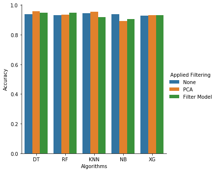

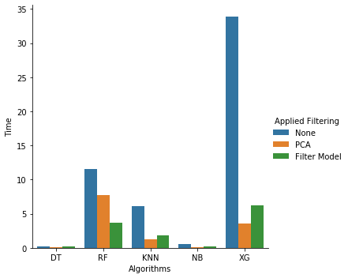

```python
get_final_bar_plot('acc')
get_final_bar_plot('time')
```

### Auxiliary Functions

```python
def get_conf_matrix(y_real, y_pred):
    # Creates a confusion matrix
    cm = confusion_matrix(y_real, y_pred)
    # Transform to df for easier plotting
    cm_df = pd.DataFrame(cm,
                         index = ['0','1'],
                         columns = ['0','1'])
    print(cm_df)

    plt.figure(figsize=(5.5,4))
    sns.heatmap(cm_df, annot=True)
    plt.title('Confusion Matrix \nAccuracy:{0:.2f}'.format(accuracy_score(y_real, y_pred)))
    plt.ylabel('True label')
    plt.xlabel('Predicted label')
    plt.show()
```

```python
def get_pie_chart(colX, colY):
    from matplotlib.gridspec import GridSpec
    import matplotlib.gridspec as gridspec

    fig, axes = plt.subplots(figsize=(18,8))
    gs = gridspec.GridSpec(1, 3)

    for i, x in zip(range(0, len(list(df.iloc[:, colX:colY]))), list(df.iloc[:, colX:colY])):
        plt.subplot(gs[0, i])
        sizes = []
        explode = []
        uniques = df[x].unique()
        labels = list(uniques)
        colors = ['orange', 'aquamarine', 'antiquewhite','chocolate', 'darkgray', 'yellow', 'purple', 'lightcoral', 'green', 'darkorchid', 'forestgreen', 'goldenrod', 'greenyellow']

        for e in uniques:
            sizes.append(len(df[df[x]==e]))
            explode.append(0)

        plt.pie(sizes, explode=explode, labels=labels, colors=colors, autopct='%1.1f%%', shadow=True, startangle=140)
        plt.axis('equal')
    plt.show()
```

```python
def get_final_bar_plot(typeplot):

    if typeplot == 'acc':
        data = {
        'Algorithms':['DT','RF','KNN','NB','XG','DT','RF','KNN','NB','XG','DT','RF','KNN','NB','XG'],
        'Applied Filtering': ['None', 'None', 'None','None','None','PCA', 'PCA', 'PCA', 'PCA','PCA','Filter Model', 'Filter Model', 'Filter Model', 'Filter Model','Filter Model'],
        'Accuracy': [acc_nfold_dt, acc_nfold_rf, acc_nfold_knn, acc_nfold_nb,acc_nfold_xg, acc_nfold_dt_pca, acc_nfold_rf_pca, acc_nfold_knn_pca, acc_nfold_nb_pca,acc_nfold_xg_pca, acc_nfold_dt_fil, acc_nfold_rf_fil,acc_nfold_knn_fil, acc_nfold_nb_fil,acc_nfold_xg_fil]
       }
        dt_acc = pd.DataFrame(data)
        print(dt_acc)
        sns.factorplot(x='Algorithms', y='Accuracy', hue='Applied Filtering', data=dt_acc, kind='bar')
    elif typeplot == 'time':
        data = {
        'Algorithms':['DT','RF','KNN','NB','XG','DT','RF','KNN','NB','XG','DT','RF','KNN','NB','XG'],
        'Applied Filtering': ['None', 'None', 'None','None','None','PCA','PCA', 'PCA', 'PCA','PCA','Filter Model', 'Filter Model', 'Filter Model', 'Filter Model','Filter Model'],
        'Time': [kfold_time_dt, kfold_time_rf, kfold_time_knn, kfold_time_nb,kfold_time_xg, kfold_time_dt_pca, kfold_time_rf_pca, kfold_time_knn_pca, kfold_time_nb_pca,kfold_time_xg_pca, kfold_time_dt_fil, kfold_time_rf_fil, kfold_time_knn_fil, kfold_time_nb_fil,kfold_time_xg_fil]
       }
        dt_time = pd.DataFrame(data)
        print(dt_time)
        sns.factorplot(x='Algorithms', y='Time', hue='Applied Filtering', data=dt_time, kind='bar')
```

```python
def get_plots(variable):
    new_var=df[['class', variable]]
    sns.factorplot('class', col=variable, data=new_var, kind='count', size=2.5, aspect=.8, col_wrap=4)
```